# Diamonds Model homework

```r
library(tidyverse)
```

1. Load the diamonds.csv data set and undertake an initial exploration of the data.

```r
diamonds <- read_csv("data/diamonds.csv")
summary(diamonds)
```

```
       X1            carat            cut               color
 Min.   :    1   Min.   :0.2000   Length:53940       Length:53940
 1st Qu.:13486   1st Qu.:0.4000   Class :character   Class :character
 Median :26970   Median :0.7000   Mode  :character   Mode  :character
 Mean   :26970   Mean   :0.7979
 3rd Qu.:40455   3rd Qu.:1.0400
 Max.   :53940   Max.   :5.0100
   clarity              depth           table           price             x
 Length:53940       Min.   :43.00   Min.   :43.00   Min.   :  326   Min.   : 0.000
 Class :character   1st Qu.:61.00   1st Qu.:56.00   1st Qu.:  950   1st Qu.: 4.710
 Mode  :character   Median :61.80   Median :57.00   Median : 2401   Median : 5.700
                    Mean   :61.75   Mean   :57.46   Mean   : 3933   Mean   : 5.731
                    3rd Qu.:62.50   3rd Qu.:59.00   3rd Qu.: 5324   3rd Qu.: 6.540
                    Max.   :79.00   Max.   :95.00   Max.   :18823   Max.   :10.740
       y                z
 Min.   : 0.000   Min.   : 0.000
 1st Qu.: 4.720   1st Qu.: 2.910
 Median : 5.710   Median : 3.530
 Mean   : 5.735   Mean   : 3.539
 3rd Qu.: 6.540   3rd Qu.: 4.040
 Max.   :58.900   Max.   :31.800
```

```r
head(diamonds)
```

| X1 | carat | cut | color | clarity | depth | table | price | x | y | z |
| --- | --- | --- | --- | --- | --- | --- | --- | --- | --- | --- |
| 1 | 0.23 | Ideal | E | SI2 | 61.5 | 55 | 326 | 3.95 | 3.98 | 2.43 |
| 2 | 0.21 | Premium | E | SI1 | 59.8 | 61 | 326 | 3.89 | 3.84 | 2.31 |
| 3 | 0.23 | Good | E | VS1 | 56.9 | 65 | 327 | 4.05 | 4.07 | 2.31 |
| 4 | 0.29 | Premium | I | VS2 | 62.4 | 58 | 334 | 4.20 | 4.23 | 2.63 |
| 5 | 0.31 | Good | J | SI2 | 63.3 | 58 | 335 | 4.34 | 4.35 | 2.75 |
| 6 | 0.24 | Very Good | J | VVS2 | 62.8 | 57 | 336 | 3.94 | 3.96 | 2.48 |

| X1 | carat | cut | color | clarity | depth | table | price | length_mm | width_mm | depth_mm |
| --- | --- | --- | --- | --- | --- | --- | --- | --- | --- | --- |
| 1 | 0.23 | Ideal | E | SI2 | 61.5 | 55 | 326 | 3.95 | 3.98 | 2.43 |
| 2 | 0.21 | Premium | E | SI1 | 59.8 | 61 | 326 | 3.89 | 3.84 | 2.31 |
| 3 | 0.23 | Good | E | VS1 | 56.9 | 65 | 327 | 4.05 | 4.07 | 2.31 |
| 4 | 0.29 | Premium | I | VS2 | 62.4 | 58 | 334 | 4.20 | 4.23 | 2.63 |
| 5 | 0.31 | Good | J | SI2 | 63.3 | 58 | 335 | 4.34 | 4.35 | 2.75 |
| 6 | 0.24 | Very Good | J | VVS2 | 62.8 | 57 | 336 | 3.94 | 3.96 | 2.48 |

2. We expect the carat of the diamonds to be strong correlated with the physical dimensions x, y and z. Use ggpairs() to investigate correlations between these four variables.

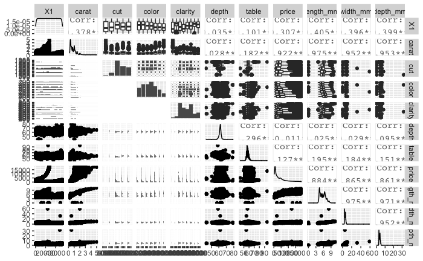

```r
summary(test_model)
```

```
Call:
lm(formula = price ~ length_mm + width_mm + depth_mm, data = diamonds)

Residuals:
   Min     1Q Median     3Q    Max
-10958  -1269   -187    975  32147

Coefficients:
             Estimate Std. Error  t value Pr(>|t|)
(Intercept) -14113.05      41.76 -337.936  < 2e-16 ***
length_mm     2790.32      40.98   68.082  < 2e-16 ***
width_mm       218.79      31.56    6.932 4.21e-12 ***
depth_mm       225.91      47.57    4.749 2.05e-06 ***
---
Signif. codes:  0 ‘***’ 0.001 ‘**’ 0.01 ‘*’ 0.05 ‘.’ 0.1 ‘ ’ 1

Residual standard error: 1860 on 53936 degrees of freedom
Multiple R-squared:  0.7825,    Adjusted R-squared:  0.7825
F-statistic: 6.47e+04 on 3 and 53936 DF,  p-value: < 2.2e-16
```

So, we do find significant correlations. Let’s drop columns x, y and z from the dataset, in preparation to use only carat going forward.

| carat | cut | color | clarity | depth | table | price |
| --- | --- | --- | --- | --- | --- | --- |
| 0.23 | Ideal | E | SI2 | 61.5 | 55 | 326 |
| 0.21 | Premium | E | SI1 | 59.8 | 61 | 326 |
| 0.23 | Good | E | VS1 | 56.9 | 65 | 327 |
| 0.29 | Premium | I | VS2 | 62.4 | 58 | 334 |
| 0.31 | Good | J | SI2 | 63.3 | 58 | 335 |
| 0.24 | Very Good | J | VVS2 | 62.8 | 57 | 336 |

4. We are interested in developing a regression model for the price of a diamond in terms of the possible predictor variables in the dataset.

```r
summary(test_model2)
```

```
Call:
lm(formula = price ~ carat, data = diamonds_trim)

Residuals:
     Min       1Q   Median       3Q      Max
-18585.3   -804.8    -18.9    537.4  12731.7

Coefficients:
            Estimate Std. Error t value Pr(>|t|)
(Intercept) -2256.36      13.06  -172.8   <2e-16 ***
carat        7756.43      14.07   551.4   <2e-16 ***
---
Signif. codes:  0 ‘***’ 0.001 ‘**’ 0.01 ‘*’ 0.05 ‘.’ 0.1 ‘ ’ 1

Residual standard error: 1549 on 53938 degrees of freedom
Multiple R-squared:  0.8493,    Adjusted R-squared:  0.8493
F-statistic: 3.041e+05 on 1 and 53938 DF,  p-value: < 2.2e-16
```

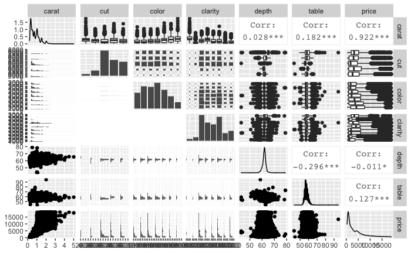

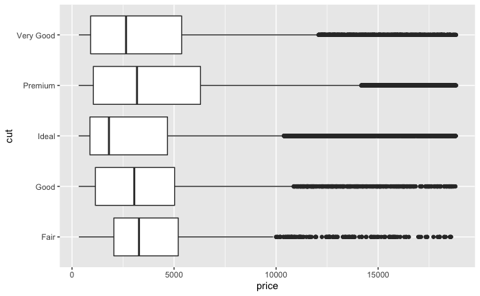

```r
diamonds_trim %>%
  ggplot(aes(x = price, y = cut))+
  geom_boxplot()
```

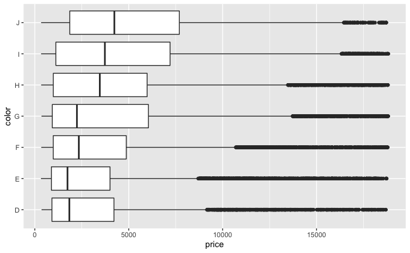

```r
diamonds_trim %>%
  ggplot(aes(x = price, y = color))+
  geom_boxplot()
```

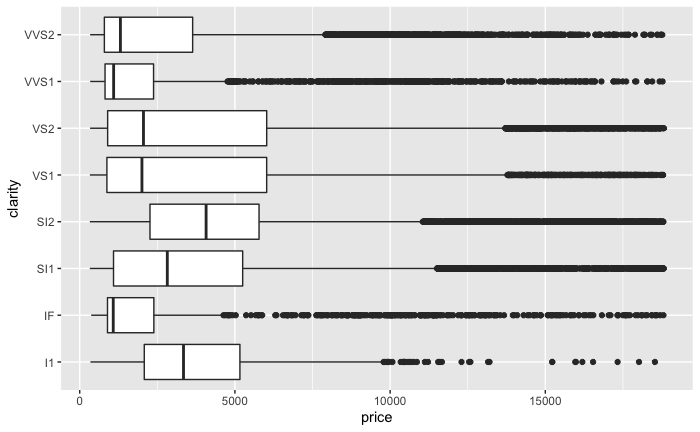

```r
diamonds_trim %>%
  ggplot(aes(x = price, y = clarity))+
  geom_boxplot()
```

5. Shortly we may try a regression fit using one or more of the categorical predictors cut, clarity and color, so let’s investigate these predictors

```r
library(fastDummies)

diamonds_dummy <- diamonds_trim %>%
  dummy_cols(select_columns = c("cut", "clarity", "color"),
                                remove_first_dummy = TRUE,
                                remove_selected_columns = FALSE)

#View(diamonds_dummy)
```

6 i. First, we’ll start with simple linear regression. Regress price on carat and check the regression diagnostics.

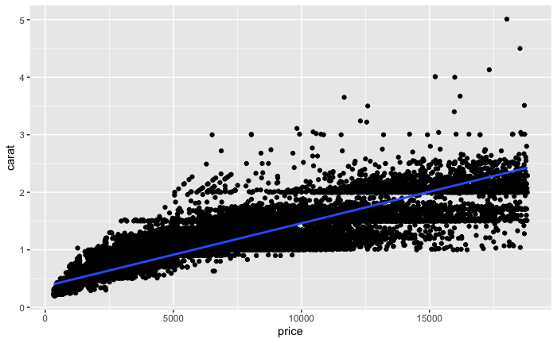

```r
diamonds_dummy %>%
  ggplot(aes(x = price, y = carat))+
  geom_point()+
  geom_smooth(method = "lm", se = FALSE)
```

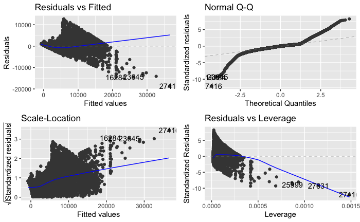

Run a regression with one or both of the predictor and response variables log() transformed and recheck the diagnostics. Do you see any improvement?

```r
diamonds_transformed_model <- lm(log(price) ~ log(carat), data = diamonds_dummy)
summary(diamonds_transformed_model)
autoplot(diamonds_transformed_model)
```

[output not shown]

This is reduntant, as makes much more sense after the homework review.

Let’s use log() transformations of both predictor and response. Next, experiment with adding a single categorical predictor into the model. Which categorical predictor is best? [Hint - investigate r2 values]